# Probabilidades empíricas

Diego Lozoya

2025-02-18

# Supuestos iniciales

Vamos a simular el comportmiento del precio de un activo que está determinado por la ecuación

$$dS=0.25Sdt + 0.15SdW$$

Con parámetros anuales con valor inicial de 10.

Usaremos este comportamiento para determinar probabilidades sobre el precio. Lo primero que nececito es determinar quien es S, que sigue el comportamiento descrito por la ecuación ds.

Para determinar S, usamos el lema de Ito y obtemenos:

$$S_{t+1}=S_t
e^{(0.25-\frac{1}{2}0.15^2)dt+0.15 dW}$$

## Objetivos

Usaremos la ecuación para generar simulaciones y obtener: - Precio esperado para dentro de 1 año - Probabilidad de que el precio sea mayor a 10 en un año - Probabilidad de que el precio supere 12 en un año - Probabilidad de que el precio se ubique entre 11 y 13 en un año - Intervalo de confianza para el precio en un año al 90%

# Definir valores iniciales

```r
set.seed(123)
S0 <- 10
mu <- 0.25
sigma <- 0.15
T <- 1 #El tiempo se escribe en años, utilizamos 1 porque vamos a predecir dentro de un año
dt <- T/252 #El dt es diario, por lo que se divide entre los numeros que cotiza la bolsa en el año
t <- seq(0, T, length.out=252)
```

# Proceso de Wiener

Vamos a simular dW, el proceso de Wiener

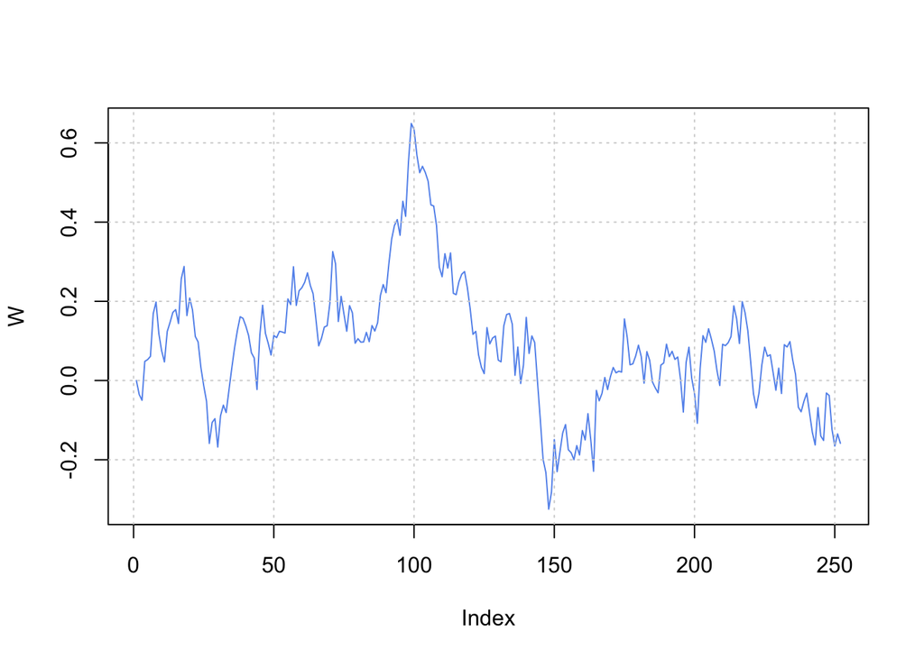

```r
W <- c(0, cumsum(sqrt(dt)*rnorm(251)))
plot(W, type="l", col="cornflowerblue")
grid()
```

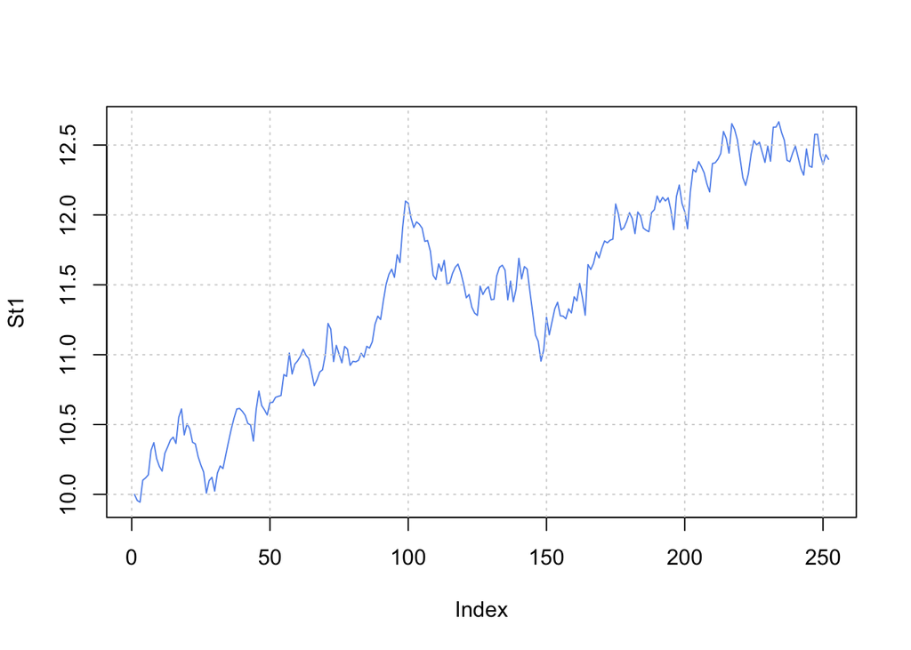

```r
St1 <- S0*exp((mu-0.5*sigma^2)*t+sigma*W)
plot(St1, type="l", col="cornflowerblue")
grid()
```

# Simulación del precio

Vamos a hacer múltiples simulaciones de este comportamiento

```r
sim <- 1000000
Pfinal <- numeric(sim) # guardaremos el precio final de cada simulación

for (i in 1:sim) {
  W <- c(0, cumsum(sqrt(dt)*rnorm(251)))
  St1 <- S0*exp((mu-0.5*sigma^2)*t+sigma*W)
  Pfinal[i] <- St1[252]
}
```

## Histograma

La distribución de probabilidad del precio para dentro de un año con un millon de simulaciones es:

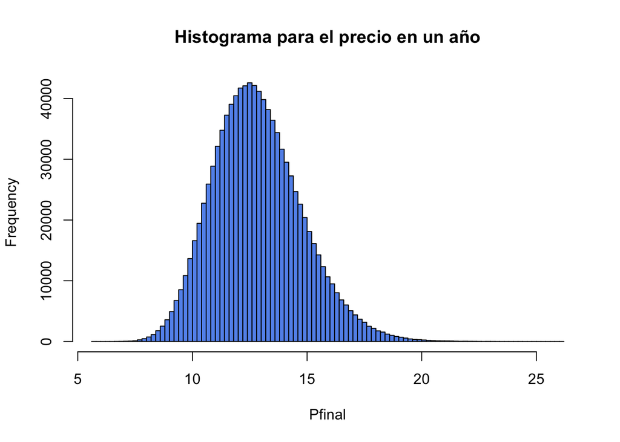

```r
hist(Pfinal, n=100, col="cornflowerblue", main="Histograma para el precio en un año")
```

## Precio esperado

```r
mean(Pfinal)
```

```
## [1] 12.84015
```

## P(S > 10)

Probabilidad de que el precio sea mayor a 10 en 1 año

```r
mean(Pfinal>10)
```

```
## [1] 0.944551
```

## P(S > 12)

```r
mean(Pfinal>12)
```

```
## [1] 0.64729
```

## P(11 < S < 13)

```r
mean(Pfinal<13 & Pfinal>11)
```

```
## [1] 0.393403
```

## Intervalo de confianza al 90%

```r
quantile(Pfinal, 0.05)
```

```
##     5%
## 9.9267
```

```r
quantile(Pfinal, 0.95)
```

```
##      95%
## 16.23997
```

# Actividad

Bajar el precio de un activo que no cotice en BMV y vas a usar el ultimo año de información para calcular mu y sigma y con eso vas a calcular la probabilidad de que el precio incremente un 30% de su valor actual en un año.

## pkgs

```r
library(quantmod)
library(lubridate)
```

## Data

```r
clave <- "COST"
datos <- new.env()

getSymbols(clave, from=today() - years(1), to=today(), env=datos)
```

```
## [1] "COST"
```

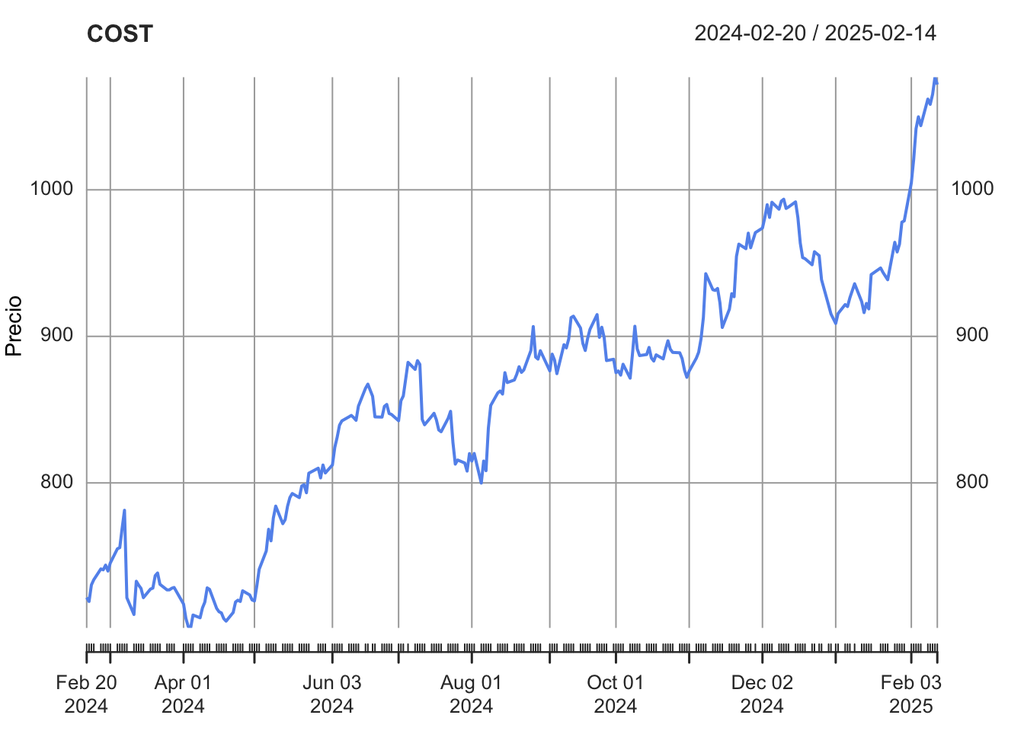

```r
precio <- datos[[clave]][,6]

plot(precio, type="l", ylab="Precio", col="cornflowerblue", main=clave)
```

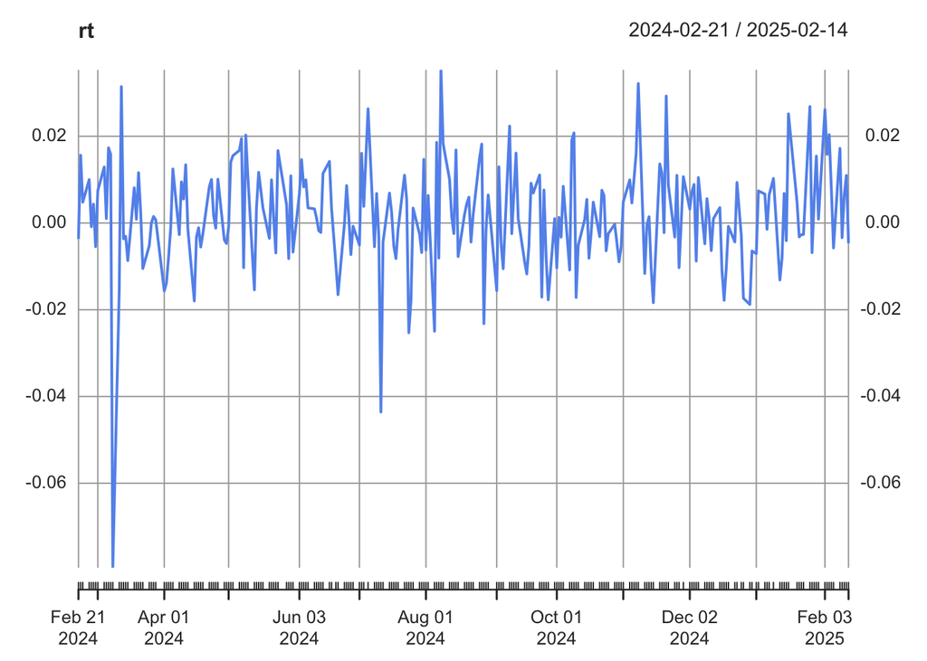

```r
rt <- na.omit(diff(log(precio)))
plot(rt, col="cornflowerblue")
```

## Parámetros

```r
mu <-  mean(rt)*252
sigma <-  sd(rt)*sqrt(252)
S0 <- as.numeric(tail(precio, 1))
T <- 1
dt <- T/252
t <- seq(0, T, length.out=252)
```

## Simulación

```r
sim <- 1000000
Pfinal <- numeric(sim)

for (i in 1:sim) {
  W <- c(0, cumsum(sqrt(dt)*rnorm(251)))
  St1 <- S0*exp((mu-0.5*sigma^2)*t+sigma*W)
  Pfinal[i] <- St1[252]
}
```

## P(S > 1.3S)

```r
mean(Pfinal>S0*1.3)
```

```
## [1] 0.731166
```

Hay un 73.12% de probabilidad de que el precio de COST aumente un 30% en el próximo año.